# Session 4: Introduction to Generalised Additive Models

From straight lines to smooth functions

Oscar Rodriguez de Rivera | University of Exeter

# 1 Session overview

## 1.1 Where this document fits

In the previous sessions, we fitted models where the relationship between a predictor and the response was usually assumed to be linear on the link scale.

For example, in a GLM or GLMM, the linear predictor was often written as:

$$\eta_i = \beta_0 + \beta_1 x_{1i} + \beta_2 x_{2i} + \cdots$$

This is powerful, but it can be restrictive. Many ecological and environmental relationships are not straight lines.

For example:

- species abundance may peak at intermediate temperature;
- growth may increase rapidly at first and then level off;
- pollution may change nonlinearly through time;
- biodiversity may respond to elevation in a curved way;
- disease risk may vary smoothly across space.

A **Generalised Additive Model**, or **GAM**, allows us to replace some linear terms with smooth functions:

$$\eta_i = \beta_0 + f_1(x_{1i}) + f_2(x_{2i}) + \cdots$$

The function (f_1(x)) is estimated from the data. This gives the model flexibility while still keeping a regression-style structure.

## 1.2 Main question

In this session, we ask:

> How can we model nonlinear relationships without forcing a straight line or choosing an arbitrary polynomial?

## 1.3 Learning outcomes

By the end of this document, students should be able to:

1. explain why a straight line may be too restrictive;
2. fit a simple GAM using `mgcv::gam()`;
3. interpret smooth terms;
4. interpret effective degrees of freedom, or EDF;
5. compare linear, polynomial and smooth models;
6. understand the role of the smoothing penalty;
7. use `gam.check()` to assess model diagnostics;
8. explain GAM results to an applied audience.

# 2 Setup

## 2.1 Packages

```r
install.packages(c("tidyverse", "mgcv"))
```

```r
library(tidyverse)
library(mgcv)

theme_set(theme_minimal(base_size = 12))
```

# 3 Why do we need GAMs?

## 3.1 Linear models are useful but restrictive

A simple linear model assumes that the response changes at a constant rate with the predictor.

For example:

$$y_i = \beta_0 + \beta_1 x_i + \varepsilon_i$$

This means that a one-unit increase in (x) has the same effect everywhere along the range of (x).

That may be unrealistic.

For example, a species might respond positively to temperature up to an optimum, and then decline when temperature becomes too high. A straight line cannot represent that pattern.

## 3.2 GAMs allow smooth nonlinear effects

A GAM replaces the straight-line term with a smooth function:

$$y_i = \beta_0 + f(x_i) + \varepsilon_i$$

The smooth function is flexible, but not completely unconstrained. The model uses a penalty to avoid overly wiggly curves.

This balance is the key idea behind GAMs:

> flexible enough to capture nonlinear structure, but penalised enough to avoid overfitting.

# 4 Simulated nonlinear data

## 4.1 Create a nonlinear relationship

We start with simulated data where the true relationship is nonlinear.

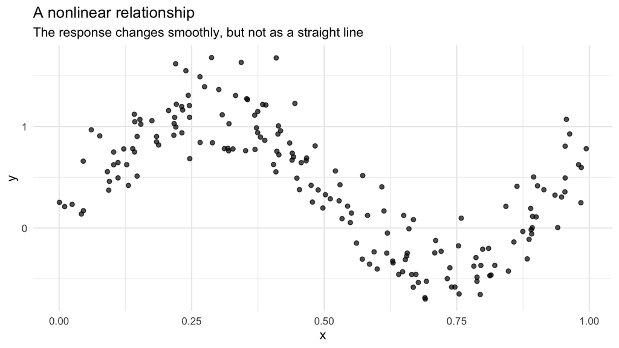

```r
set.seed(123)

nonlinear_dat <- tibble(
  x = sort(runif(180, 0, 1)),
  y = sin(2 * pi * x) + 0.8 * x + rnorm(180, sd = 0.25)
)

ggplot(nonlinear_dat, aes(x = x, y = y)) +
  geom_point(alpha = 0.7) +
  labs(
    x = "x",
    y = "y",
    title = "A nonlinear relationship",
    subtitle = "The response changes smoothly, but not as a straight line"
  )
```

## 4.2 Interpretation

The scatterplot shows a clear pattern, but the pattern is not linear.

The response rises and falls across the range of (x). A straight line would miss this structure.

This is the type of situation where a GAM can be useful.

# 5 Linear and polynomial models

## 5.1 Fit a linear model

```r
lm_fit <- lm(
  y ~ x,
  data = nonlinear_dat
)

summary(lm_fit)
```

```
##
## Call:
## lm(formula = y ~ x, data = nonlinear_dat)
##
## Residuals:
##      Min       1Q   Median       3Q      Max
## -0.88574 -0.37895  0.01563  0.33668  1.22737
##
## Coefficients:
##             Estimate Std. Error t value Pr(>|t|)
## (Intercept)  1.07404    0.07464  14.390   <2e-16 ***
## x           -1.28610    0.13075  -9.836   <2e-16 ***
## ---
## Signif. codes:  0 '***' 0.001 '**' 0.01 '*' 0.05 '.' 0.1 ' ' 1
##
## Residual standard error: 0.4824 on 178 degrees of freedom
## Multiple R-squared:  0.3521, Adjusted R-squared:  0.3485
## F-statistic: 96.75 on 1 and 178 DF,  p-value: < 2.2e-16
```

The linear model estimates one intercept and one slope.

It is easy to interpret, but it is too rigid for this dataset.

## 5.2 Fit polynomial models

A polynomial model adds powers of (x), such as (x^2), (x^3) and so on.

Polynomials can represent curves, but high-order polynomials can behave badly, especially near the edges of the data.

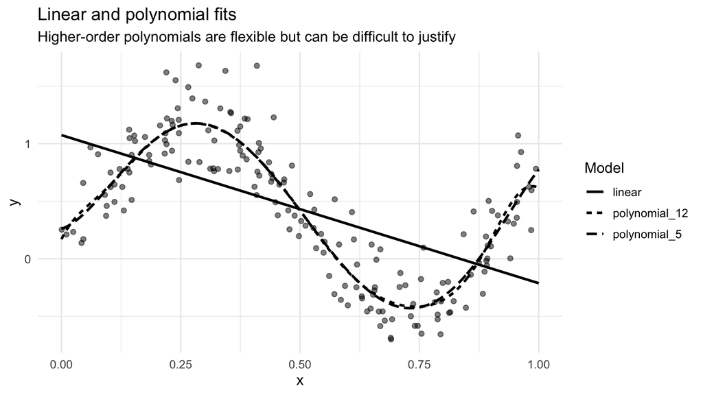

```r
poly5_fit <- lm(
  y ~ poly(x, 5),
  data = nonlinear_dat
)

poly12_fit <- lm(
  y ~ poly(x, 12),
  data = nonlinear_dat
)

grid_x <- tibble(
  x = seq(0, 1, length.out = 300)
) %>%
  mutate(
    linear = predict(lm_fit, newdata = .),
    polynomial_5 = predict(poly5_fit, newdata = .),
    polynomial_12 = predict(poly12_fit, newdata = .)
  ) %>%
  pivot_longer(
    cols = c(linear, polynomial_5, polynomial_12),
    names_to = "model",
    values_to = "fit"
  )

ggplot(nonlinear_dat, aes(x = x, y = y)) +
  geom_point(alpha = 0.5) +
  geom_line(
    data = grid_x,
    aes(y = fit, linetype = model),
    linewidth = 1
  ) +
  labs(
    x = "x",
    y = "y",
    linetype = "Model",
    title = "Linear and polynomial fits",
    subtitle = "Higher-order polynomials are flexible but can be difficult to justify"
  )
```

## 5.3 Why not just use a high-order polynomial?

Polynomials are useful in some situations, but they have limitations.

A high-order polynomial:

- can be hard to interpret;
- may behave unpredictably near the edges;
- can be sensitive to a few observations;
- requires the analyst to choose the degree of the polynomial;
- may fit local wiggles that are not scientifically meaningful.

GAMs offer a more principled approach. They estimate a smooth curve while penalising excessive wiggliness.

# 6 Fitting a GAM

## 6.1 Basic GAM syntax

The basic `mgcv` syntax is:

```r
mgcv::gam(
  response ~ s(covariate),
  data = my_data,
  family = gaussian(),
  method = "REML"
)
```

The function `s()` tells R to estimate a smooth function of the covariate.

For example:

```r
y ~ s(x)
```

means:

> model (y) as a smooth function of (x).

## 6.2 Fit a simple GAM

```r
gam_fit <- mgcv::gam(
  y ~ s(x, k = 12),
  data = nonlinear_dat,
  family = gaussian(),
  method = "REML"
)

summary(gam_fit)
```

```
##
## Family: gaussian
## Link function: identity
##
## Formula:
## y ~ s(x, k = 12)
##
## Parametric coefficients:
##             Estimate Std. Error t value Pr(>|t|)
## (Intercept)  0.43073    0.01827   23.58   <2e-16 ***
## ---
## Signif. codes:  0 '***' 0.001 '**' 0.01 '*' 0.05 '.' 0.1 ' ' 1
##
## Approximate significance of smooth terms:
##       edf Ref.df     F p-value
## s(x) 7.67  9.072 97.69  <2e-16 ***
## ---
## Signif. codes:  0 '***' 0.001 '**' 0.01 '*' 0.05 '.' 0.1 ' ' 1
##
## R-sq.(adj) =  0.832   Deviance explained = 83.9%
## -REML = 17.729  Scale est. = 0.060081  n = 180
```

## 6.3 Interpreting the output

The GAM summary has two important parts.

First, the **parametric coefficients** section gives the intercept.

Second, the **smooth terms** section gives information about `s(x)`.

The smooth table includes:

- `edf`: effective degrees of freedom;
- `Ref.df`: reference degrees of freedom used for testing;
- `F`: approximate test statistic;
- `p-value`: evidence that the smooth term is associated with the response.

For teaching, the most important value is usually the EDF.

# 7 What is EDF?

## 7.1 Effective degrees of freedom

EDF stands for **effective degrees of freedom**.

It describes how flexible the smooth is.

A useful rule of thumb is:

| EDF | Interpretation |
| --- | --- |
| close to 1 | approximately linear |
| between 2 and 4 | moderately nonlinear |
| larger values | more flexible nonlinear pattern |

An EDF of 1 means the smooth is behaving almost like a straight line.

An EDF greater than 1 means the model has used nonlinear flexibility.

```r
summary(gam_fit)$s.table
```

```
##           edf   Ref.df        F p-value
## s(x) 7.669525 9.071843 97.69182       0
```

## 7.2 Important caution

A high EDF is not automatically good.

A very flexible curve may fit noise rather than signal. This is why GAMs use smoothing penalties and why diagnostics are important.

The key question is:

> Is the amount of wiggliness supported by the data and scientifically interpretable?

# 8 Plotting the smooth fit

## 8.1 Generate predictions

```r
gam_pred <- tibble(
  x = seq(0, 1, length.out = 300)
)

gam_prediction <- predict(
  gam_fit,
  newdata = gam_pred,
  se.fit = TRUE
)

gam_pred <- gam_pred %>%
  mutate(
    fit = as.numeric(gam_prediction$fit),
    se.fit = as.numeric(gam_prediction$se.fit),
    lower = fit - 1.96 * se.fit,
    upper = fit + 1.96 * se.fit
  )

head(gam_pred)
```

| x | fit | se.fit | lower | upper |
| --- | --- | --- | --- | --- |
| 0.000000000 | 0.2210751 | 0.1238521 | -0.021674977 | 0.4638252 |
| 0.003344482 | 0.2346373 | 0.1190304 | 0.001337631 | 0.4679369 |
| 0.006688963 | 0.2482014 | 0.1142953 | 0.024182649 | 0.4722201 |
| 0.010033445 | 0.2617699 | 0.1096601 | 0.046835980 | 0.4767038 |
| 0.013377926 | 0.2753453 | 0.1051396 | 0.069271775 | 0.4814189 |
| 0.016722408 | 0.2889314 | 0.1007501 | 0.091461266 | 0.4864016 |

## 8.2 Plot fitted smooth with confidence band

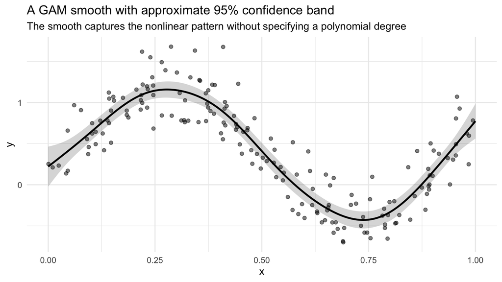

```r
ggplot(nonlinear_dat, aes(x = x, y = y)) +
  geom_point(alpha = 0.5) +
  geom_ribbon(
    data = gam_pred,
    aes(x = x, ymin = lower, ymax = upper),
    alpha = 0.2,
    inherit.aes = FALSE
  ) +
  geom_line(
    data = gam_pred,
    aes(x = x, y = fit),
    linewidth = 1
  ) +
  labs(
    x = "x",
    y = "y",
    title = "A GAM smooth with approximate 95% confidence band",
    subtitle = "The smooth captures the nonlinear pattern without specifying a polynomial degree"
  )
```

## 8.3 Interpretation

The fitted curve follows the main nonlinear pattern in the data.

The shaded band gives approximate uncertainty around the fitted mean response.

The uncertainty is usually larger where data are sparse or where the curve is less well constrained.

# 9 The basis dimension `k`

## 9.1 What does `k` do?

The argument `k` sets the maximum flexibility available to the smooth.

It does **not** directly set the EDF.

Instead:

- `k` sets an upper limit on complexity;
- the smoothing penalty decides how much complexity is actually used.

A common misunderstanding is to think that `k = 12` means the smooth will use 12 degrees of freedom. It does not. The model may use much less flexibility if the data do not support a wiggly curve.

## 9.2 Compare different values of `k`

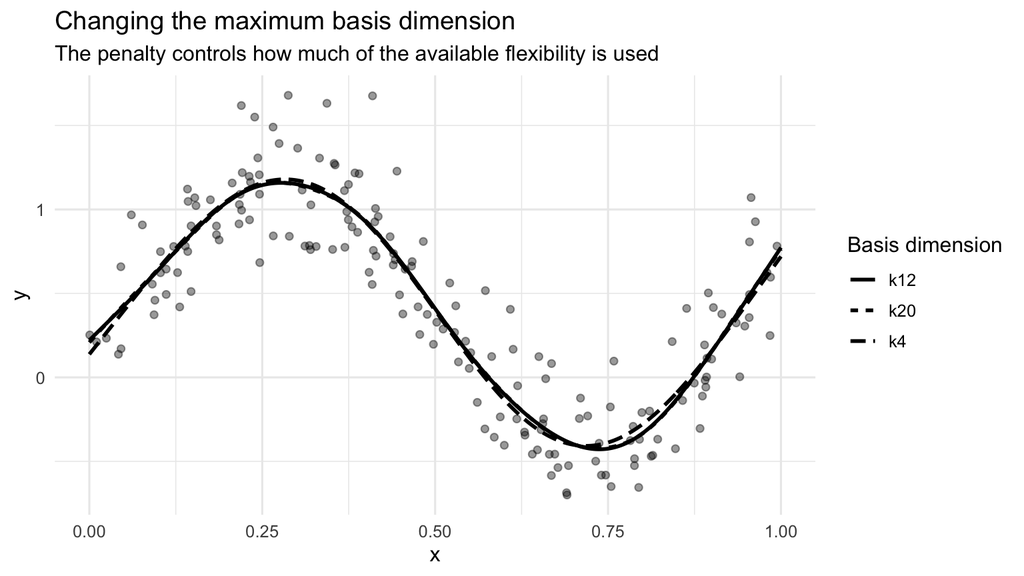

```r
gam_k4 <- mgcv::gam(
  y ~ s(x, k = 4),
  data = nonlinear_dat,
  method = "REML"
)

gam_k20 <- mgcv::gam(
  y ~ s(x, k = 20),
  data = nonlinear_dat,
  method = "REML"
)

gam_compare <- tibble(
  x = seq(0, 1, length.out = 300)
) %>%
  mutate(
    k4 = predict(gam_k4, newdata = .),
    k12 = predict(gam_fit, newdata = .),
    k20 = predict(gam_k20, newdata = .)
  ) %>%
  pivot_longer(
    cols = c(k4, k12, k20),
    names_to = "model",
    values_to = "fit"
  )

ggplot(nonlinear_dat, aes(x = x, y = y)) +
  geom_point(alpha = 0.4) +
  geom_line(
    data = gam_compare,
    aes(y = fit, linetype = model),
    linewidth = 1
  ) +
  labs(
    x = "x",
    y = "y",
    linetype = "Basis dimension",
    title = "Changing the maximum basis dimension",
    subtitle = "The penalty controls how much of the available flexibility is used"
  )
```

## 9.3 Compare EDF values

```r
edf_comparison <- tibble(
  model = c("k = 4", "k = 12", "k = 20"),
  edf = c(
    summary(gam_k4)$s.table[1, "edf"],
    summary(gam_fit)$s.table[1, "edf"],
    summary(gam_k20)$s.table[1, "edf"]
  )
)

edf_comparison
```

| model | edf |
| --- | --- |
| k = 4 | 2.995608 |
| k = 12 | 7.669525 |
| k = 20 | 8.197399 |

## 9.4 Interpretation

If `k` is too small, the smooth may not have enough flexibility to represent the pattern.

If `k` is large enough, increasing it further may not change the fitted curve much because the smoothing penalty prevents unnecessary wiggliness.

This is why `gam.check()` is useful.

# 10 The smoothing penalty

## 10.1 Why do GAMs not overfit automatically?

A smooth could be made very wiggly, but that would risk fitting noise.

GAMs control wiggliness using a **smoothing penalty**.

The model balances two goals:

1. fit the data well;
2. avoid unnecessary wiggliness.

The smoothing parameter controls this balance.

In `mgcv`, using `method = "REML"` is often recommended because it provides stable estimation of smoothing parameters.

## 10.2 Conceptual summary

A GAM is not simply a line drawn through the data.

It is a statistical model where the smoothness of the function is estimated using a penalty.

This makes GAMs flexible but still regularised.

# 11 Model checking

## 11.1 Use `gam.check()`

`gam.check()` gives residual diagnostics and checks whether `k` is large enough.

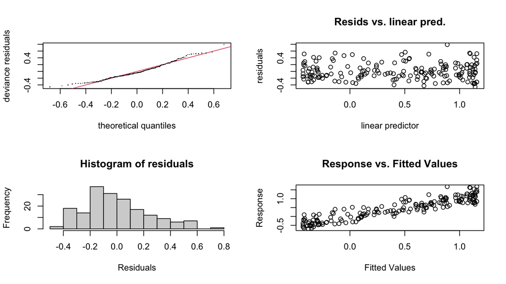

```
##
## Method: REML   Optimizer: outer newton
## full convergence after 7 iterations.
## Gradient range [-7.313799e-06,6.871283e-06]
## (score 17.72912 & scale 0.06008081).
## Hessian positive definite, eigenvalue range [3.611829,89.13024].
## Model rank =  12 / 12
##
## Basis dimension (k) checking results. Low p-value (k-index<1) may
## indicate that k is too low, especially if edf is close to k'.
##
##         k'   edf k-index p-value
## s(x) 11.00  7.67    1.05    0.72
```

```r
mgcv::gam.check(gam_fit)
```

## 11.2 Interpreting `gam.check()`

The plots help assess whether the residuals look reasonable.

The printed output includes a `k-index`.

A useful rule of thumb is:

- if the `k-index` is close to 1, `k` is probably adequate;
- if the `k-index` is low and the p-value is small, `k` may be too small;
- if diagnostics look poor, revisit the model.

This is not a mechanical rule. Diagnostics should be interpreted alongside the plot and the scientific question.

# 12 Comparing linear, polynomial and GAM models

## 12.1 AIC comparison

```r
AIC(
  lm_fit,
  poly5_fit,
  poly12_fit,
  gam_fit
)
```

|  | df | AIC |
| --- | --- | --- |
| lm_fit | 3.000000 | 252.40094 |
| poly5_fit | 7.000000 | 10.46237 |
| poly12_fit | 14.000000 | 22.99859 |
| gam_fit | 9.772979 | 15.30692 |

AIC can help compare models fitted to the same response and dataset.

However, model choice should not rely on AIC alone. We also care about:

- interpretability;
- residual diagnostics;
- whether the model is scientifically plausible;
- prediction performance;
- avoiding unnecessary complexity.

# 13 Exercise

## 13.1 Exercise: explore smooth flexibility

1. Change `k` to 5, 8 and 20. How does the smooth change?
2. Increase the noise in the simulated data. Does the EDF increase or decrease?
3. Fit a polynomial model and a GAM. Which would you rather explain to an applied audience, and why?

# 14 Exercise solution

## 14.1 1. Change `k` to 5, 8 and 20

### 14.1.1 Interpretation

If `k` is too small, the smooth may be too simple and may miss part of the nonlinear pattern.

Once `k` is large enough, increasing it further may not change the curve very much because the smoothing penalty controls the actual complexity.

The EDF tells us how much flexibility the model actually used.

## 14.2 2. Increase the noise in the simulated data

### 14.2.1 Interpretation

When the data are noisier, the true pattern is harder to estimate.

The EDF may decrease because the model is penalised against following random noise.

However, this is not guaranteed in every dataset. The effect of noise depends on the signal, sample size and smoothing penalty.

The main point is that a GAM tries to estimate the smooth pattern while avoiding unnecessary wiggliness.

## 14.3 3. Fit a polynomial model and a GAM

### 14.3.1 Interpretation

For an applied audience, the GAM is often easier to explain:

> The model estimates a smooth relationship between the predictor and the response, while penalising unnecessary wiggliness.

A high-order polynomial is harder to justify because the degree of the polynomial can feel arbitrary and the curve may behave strangely near the edges.

That said, a simple polynomial can be useful if the expected shape is simple and scientifically meaningful.

# 15 Summary

In this session, we introduced Generalised Additive Models.

Key points:

- linear models assume straight-line effects;
- many ecological and environmental relationships are nonlinear;
- GAMs estimate smooth functions of predictors;
- `s(x)` fits a smooth effect of `x`;
- EDF describes how nonlinear or flexible a smooth is;
- `k` sets the maximum possible flexibility, not the final EDF;
- the smoothing penalty controls wiggliness;
- `method = "REML"` is commonly used for stable smoothness estimation;
- `gam.check()` helps diagnose whether the model is adequate;
- predictions and plots are central to interpreting GAMs.

# 16 Link to the next document

This document used a single smooth.

Next, we will fit GAMs with several smooth terms, inspect model diagnostics and use predictions to interpret nonlinear covariate effects.

We will also connect GAMs back to ecological and environmental modelling, where nonlinear responses to time, temperature, space and other gradients are common.